# Homework 2 Parking

Catrina Zhang

2019-03-15

## Assignment Setup

In this section, I will be loading the package and data required for the assignment.

```r
library(ggplot2)
library(tidyverse)
library(gridExtra)
library(rvest)
library(stringr)
library(plotly)
library(DT)
library(devtools)
library(readr)
library(leaflet)

parkingNYC=read_csv("parkingNYC_jan2019.csv")
violationcodes=read_csv("parkingNYC_ParkingViolationCodes_Nov_2018.csv")
violationcodes = violationcodes[-1,]
```

## a) Violation Code and Fine Amounts

Add the violation code descriptions and fine amounts to the data file. Provide a visual overview of the top 10 most common types of violations (feel free to group them into categories if reasonable). Compare how this ranking differs if we focus on the total amount of revenue generated.

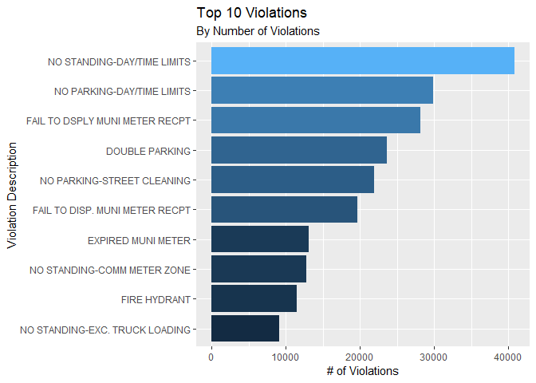

```r
violationcodes <- violationcodes %>%
  mutate(`VIOLATION CODE` = as.numeric(`VIOLATION CODE`))

parking = full_join(parkingNYC, violationcodes, by = c('Violation Code'='VIOLATION CODE'))

colnames(parking)[6] <- "VC"
colnames(parking)[48:49] <- c("VD", "Fine")
colnames(parking)[15] <- "VP"

parking2 <- parking %>%
  group_by(VC, VD, Fine) %>%
  summarize(violations = length(VC))

parking2$revenue <- parking2$violations * parking2$Fine / 1000

parking3 <- parking2 %>%
  arrange(desc(violations)) %>%
  head(10)

parking4 <- parking2 %>%
  arrange(desc(revenue)) %>%
  head(10)

TotalViolations <-
  ggplot(data = parking3, aes(x=reorder(VD, violations), y=violations, fill = violations)) +
  geom_bar(stat = "identity") +
  labs(title = "Top 10 Violations",
       subtitle = "By Number of Violations",
       x = "Violation Description", y = "# of Violations") +
  theme(legend.position = "none") +
  coord_flip()

TotalViolations
```

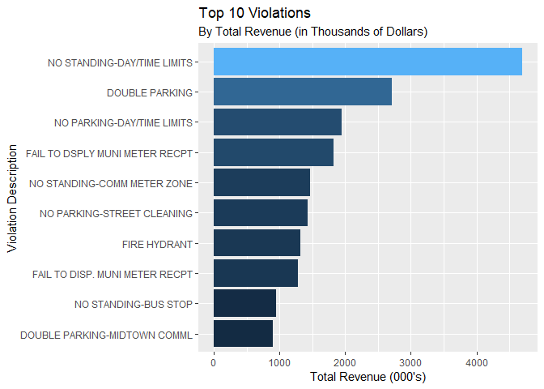

```r
RevenueViolations <-
  ggplot(data = parking4, aes(x=reorder(VD, revenue), y=revenue, fill = revenue)) +
  geom_bar(stat = "identity") +
  labs(title = "Top 10 Violations",
       subtitle = "By Total Revenue (in Thousands of Dollars)",
       x = "Violation Description", y = "Total Revenue (000's)") +
  theme(legend.position = "none") +
  coord_flip()

RevenueViolations
```

2. Average amount of fine by vehicle Compare the average amount of fine by vehicle color, vehicle year, and vehicle plate type [Hint: it is sufficient to restrict your attention to commercial (COM) and passenger (PAS) vehicles]? Briefly describe your findings.

The average fine by commercial and passenger vehicles are very similar. For the vehicle color, I grouped together some of the common color. For vehicle year, there are some vehicles that had futuer years, I simply did not include them in the results. For all three plots, the bar colors are based on the average fine amount. It seems that vehicles made between 1980 and 2000 have the highest average fines, and brown and white colored vehicles have the highest average fines.

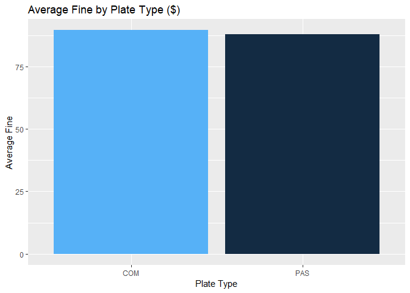

```r
parkingb <- parking %>%
  select(`Plate Type`, `Vehicle Color`, `Vehicle Year`, Fine)

colnames(parkingb) <- c("PT", "VColor", "VY", "Fine")

parkingb_0 <- parkingb %>%
  mutate(VColor=replace(VColor, VColor == "BLK"|VColor == "BK"|VColor == "BL" , "BLACK"),
         VColor=replace(VColor, VColor == "GY"|VColor == "GRY"|VColor == "GR/" , "GREY"),
         VColor=replace(VColor, VColor == "BR"|VColor == "BRN"|VColor == "BRO"|VColor == "BRW", "BROWN"),
         VColor=replace(VColor, VColor == "YEL"|VColor == "YELLO"|VColor == "YLLW"|VColor == "YL"|VColor == "YE", "YELLOW"),
         VColor=replace(VColor, VColor == "OR", "ORANGE"),
         VColor=replace(VColor, VColor == "WHI", "WHITE"),
         VColor=replace(VColor, VColor == "R"|VColor == "RD/"|VColor == "RD" , "RED"),
         VColor=replace(VColor, VColor == "GREE", "GREEN"))

parkingPT <- parkingb_0 %>%
  group_by(PT, Fine) %>%
  summarize(Freq = length(Fine)) %>%
  filter(PT == "PAS" | PT == 'COM')

parkingPT <- na.omit(parkingPT)
parkingPT$revenue <- parkingPT$Fine * parkingPT$Freq

parkingPT <- parkingPT %>% group_by(PT) %>%
  summarize(sumFreq = sum(Freq),
            sumRevenue = sum(revenue))

parkingPT$avgFine <- parkingPT$sumRevenue / parkingPT$sumFreq

finebyPT <-
  ggplot(data = parkingPT, aes(x=PT, y=avgFine, fill = avgFine)) +
  geom_bar(stat = "identity") +
  labs(title = "Average Fine by Plate Type ($)",
       x = "Plate Type", y = "Average Fine") +
  theme(legend.position = "none")

finebyPT
```

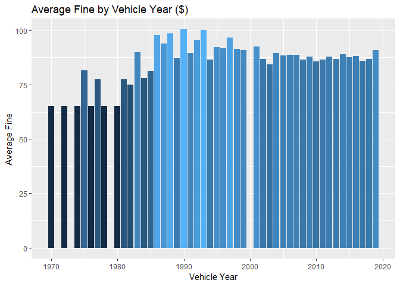

```r
## Year
parkingVY <- parkingb_0 %>%
  group_by(VY, Fine) %>%
  summarize(Freq = length(Fine)) %>%
  filter(VY > 0 & VY < 2020)

parkingVY <- na.omit(parkingVY)
parkingVY$revenue <- parkingVY$Fine * parkingVY$Freq

parkingVY <- parkingVY %>% group_by(VY) %>%
  summarize(sumFreq = sum(Freq),
            sumRevenue = sum(revenue))

parkingVY$avgFine <- parkingVY$sumRevenue / parkingVY$sumFreq

parkingVY <-
  ggplot(data = parkingVY, aes(x=VY, y=avgFine, fill = avgFine)) +
  geom_bar(stat = "identity") +
  labs(title = "Average Fine by Vehicle Year ($)",
       x = "Vehicle Year", y = "Average Fine") +
  theme(legend.position = "none")

parkingVY
```

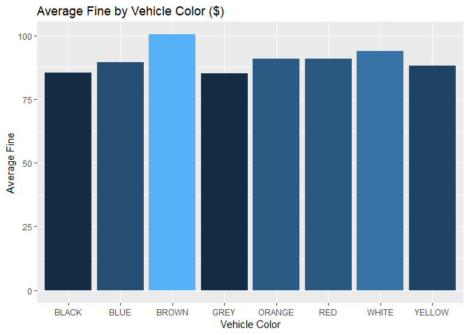

```r
parkingVC <- na.omit(parkingb_0)

vc <- c('BROWN', 'GREY', 'BLACK', 'RED', 'WHITE', 'ORANGE', 'YELLOW', 'BLUE')

parkingVC1 <- filter(parkingVC, VColor %in% vc)

parkingVC2 <- parkingVC1 %>%
  group_by(VColor, Fine) %>%
  summarize(Freq = length(Fine))

parkingVC2$revenue <- parkingVC2$Fine * parkingVC2$Freq

parkingVC3 <- parkingVC2 %>% group_by(VColor) %>%
  summarize(sumFreq = sum(Freq),
            sumRevenue = sum(revenue))

parkingVC3$avgFine <- parkingVC3$sumRevenue / parkingVC3$sumFreq

parkingVCplot <-
  ggplot(data = parkingVC3, aes(x=VColor, y=avgFine, fill = avgFine)) +
  geom_bar(stat = "identity") +
  labs(title = "Average Fine by Vehicle Color ($)",
       x = "Vehicle Color", y = "Average Fine") +
  theme(legend.position = "none")

parkingVCplot
```

## 2. Map by Precincts

Read in the shape files for the police precincts and remove all precincts outside of Manhattan.

```r
library('rgdal')
precincts <- readOGR(".", "nypp")

precincts2 <- subset(precincts, Precinct == c(1,5,6,7,9,10,13,14,17,18,19,20,22,23,24,25,26,28,30,32,33,34))

precincts3 <- spTransform(precincts2,
                          CRS("+proj=longlat +datum=WGS84"))

precincts4 <- fortify(precincts3)

precincts5 <- precincts4 %>%
  mutate(id_new = ifelse(id == 21, 34,ifelse(id == 20, 33,ifelse(id == 19, 32,ifelse(id == 18, 30,
  ifelse(id == 17, 28, ifelse(id == 16, 26, ifelse(id == 15, 25, ifelse(id == 14, 24, ifelse(id == 13, 23,
  ifelse(id == 12, 22, ifelse(id == 11, 20, ifelse(id == 10, 19, ifelse(id == 9, 18, ifelse(id == 8, 17, ifelse(id == 7, 14, ifelse(id == 6, 13, ifelse(id == 5, 13, ifelse(id == 4, 9, ifelse(id == 3, 7, ifelse(id == 2, 6, ifelse(id == 1, 5, 1))))))))))))))))))))))
```

1. Number of tickets, total fines, and average fines Provide three maps that show choropleth maps of:

the total number of tickets the total amount of fines the average amount of fines Briefly describe what you learn from these maps in comparison.

I used different shades of pink to represent the amounts - the darker the color, the larger the number. Overall, the precincts on the east and immediately south of Central Park resulted in the highest total number of ticket, total amount of fines and average amount of fines. As expected, the total number of tickets and total fines maps were quite similar in terms of which precincts had higher number of violations/fines. The average amount of fines graph was slightly different, in that the precincts directly south of Central Park had the highest average amount of fines, and some precincts in the north also had higher averages as well, whereas those precincts did not appear high on the first two maps.

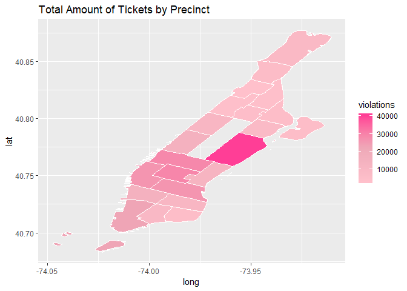

```r
library(ggmap)

parkingmap <- parking %>%
  select(VP, Fine)

parkingmap <- na.omit(parkingmap)

parkingmap2 <- parkingmap %>%
  group_by(VP) %>%
  summarize(violations = length(VP))

precinct <- precincts5 %>%
  select(long, lat, id, group, id_new) %>%
  unique()

parkingmap4 <- parkingmap %>%
  group_by(VP) %>%
  summarize(revenue = sum(Fine)/1000)

parkingmap3 <- inner_join(parkingmap2, parkingmap4, by = 'VP')

parkingmap3$avgrev <- parkingmap3$revenue / parkingmap3$violations * 1000

parkingmap5 <- inner_join(parkingmap3, precinct, by = c('VP'='id_new'))

maptickets <- ggplot(parkingmap5,
    aes(x = long, y = lat, group=group)) + scale_fill_gradientn(colours=c("pink","pink2","violetred1"))+
    geom_polygon(aes(fill = violations), color="white")+ggtitle("Total Amount of Tickets by Precinct")

maptickets
```

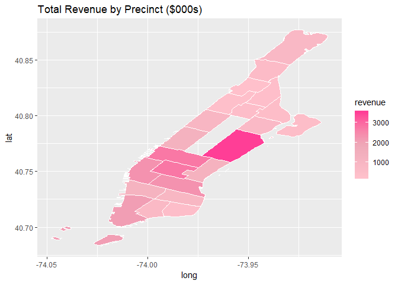

```r
maprevs <- ggplot(parkingmap5,
    aes(x = long, y = lat, group=group)) + scale_fill_gradientn(colours=c("pink","pink2","violetred1"))+
    geom_polygon(aes(fill = revenue), color="white")+ggtitle("Total Revenue by Precinct ($000s)")

maprevs
```

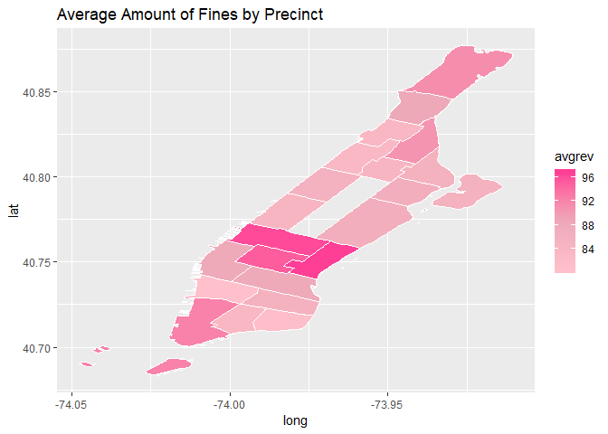

```r
mapavg <- ggplot(parkingmap5,
    aes(x = long, y = lat, group=group)) + scale_fill_gradientn(colours=c("pink","pink2","violetred1"))+
    geom_polygon(aes(fill = avgrev), color="white")+ggtitle("Average Amount of Fines by Precinct")

mapavg
```

2. Types of violations Group the almost 100 types of ticket violations into a smaller set of 4-6 subgroups (where other should be the remainder of violations not included in other groups you defined). [Hint: No need to spend more than 5 minutes thinking about what the right grouping is.]. Provide choropleth maps for each of these subgroups to show where different types of violations are more or less common.